# Day 3: Numeric Algorithms

Roberto Bruno Martins

13-08-2014

# Interpolation Methods

```r
x = seq(0, 10, length.out = 25)
y = x ^ 2 + rnorm(25,0,10)
table(x, y)
```

[output not shown]

[output cut: 188 more lines]

[output not shown]

```r
f <- approxfun(x, y)
f(0.5)
```

```
## [1] 19.34
```

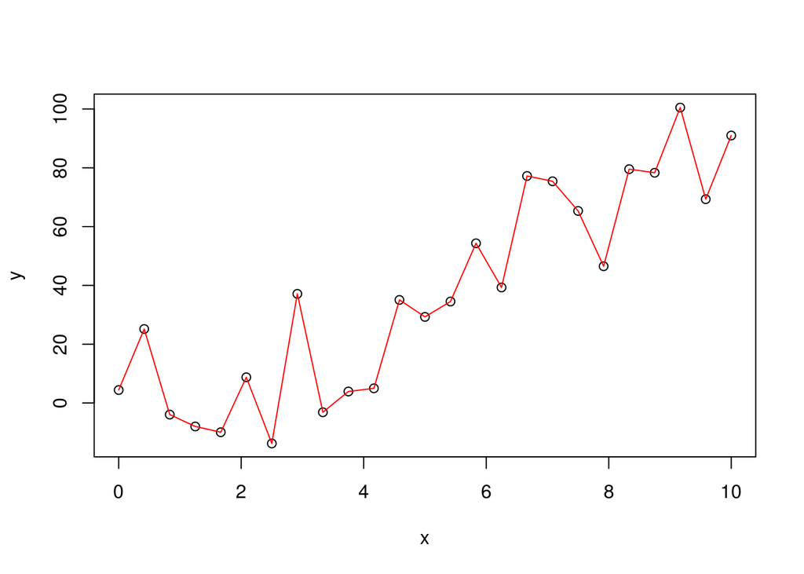

```r
plot(x,y)
curve(f, 0, 10, n=25, col = "red", add = TRUE)
```

- **Spline Interpolation**: Smoother interpolation. Implemented through `splinefun`

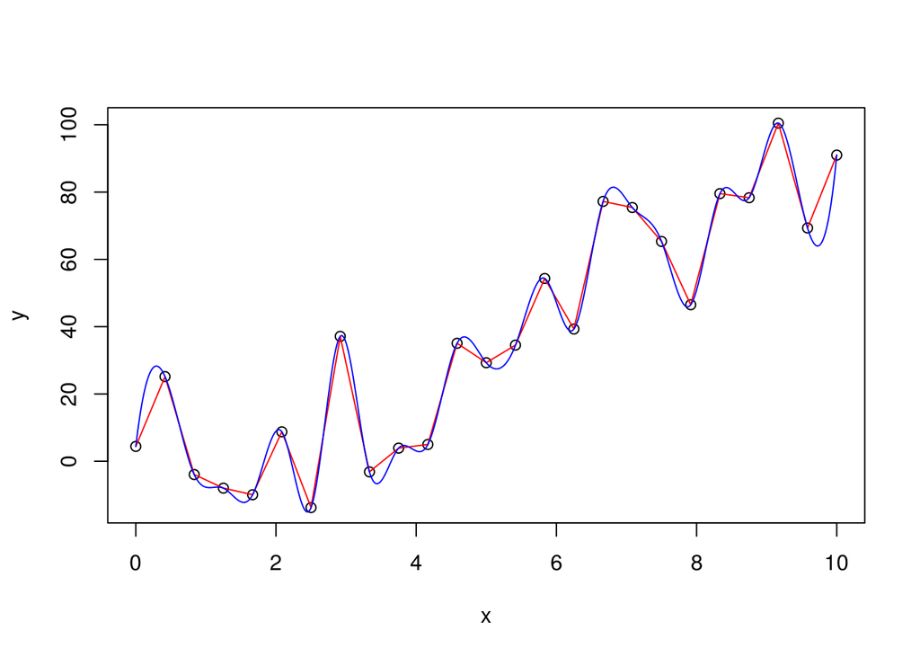

```r
g = splinefun(x, y)
plot(x,y)
curve(f, 0, 10, n=25, col = "red", add = TRUE)
curve(g, 0, 10, n=1000, add=TRUE, col="blue")
```

- **Extrapolation**: Extrapolation can have even more problems than interpolation. It’s really guessing based on an assumption (your interpolation function’s behaviour outside the data range).

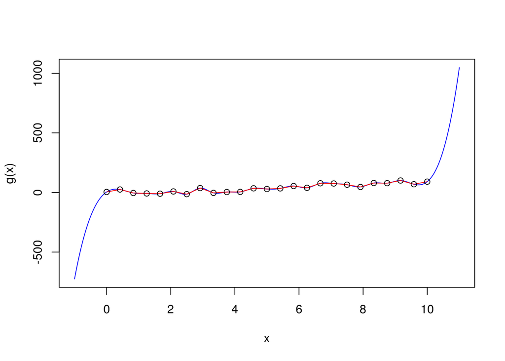

```r
curve(g, -1, 11, n=1000, col="blue")
curve(f, -5, 15, n=1000, col = "red", add=TRUE)
points(x,y)
```

- **Linear Models**: You can use the `lm.fit` function to calculate the linear model. You have to transform x and y into a matrix, with `length(y)` lines, `x` on the first column and `1` on the second.

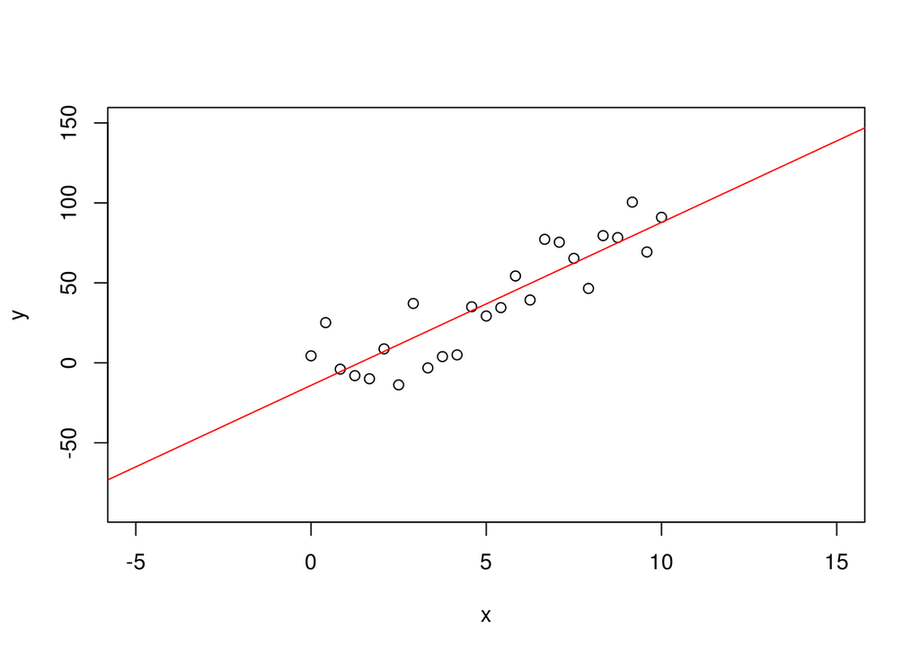

```r
myLm = lm.fit(cbind(a=x, b=1), y)
coef = myLm$coefficients
plot(x, y, xlim=c(-5, 15), ylim=c(-90, 150))
abline(coef[2], coef[1], col="red")
```

- **Other ideas**: Let’s try second-degree. `lm.fit` does that as well.

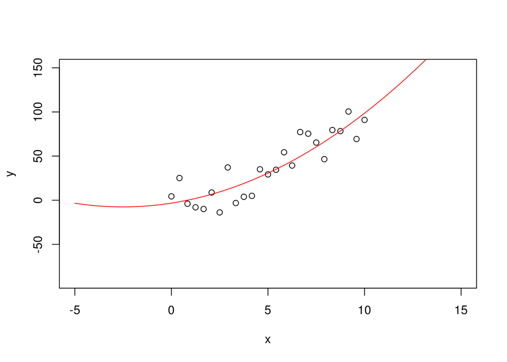

```r
myLm = lm.fit(cbind(a=x^2, b=x, c=1), y)
coef = myLm$coefficients
plot(x, y, xlim=c(-5, 15), ylim=c(-90, 150))
curve(coef[1]*x^2+ coef[2]*x+coef[3], -5, 15, n=1000, col="red", add=TRUE)
```

# Root Finding

This is about numerically finding an `x` value where `f(x)` is zero (or very close to it). In general, it is about find any value of `x` where `f(x)` is closest to some `y` value.

- **Bisection**: Depends on values at the edges of the interval having different signs. `uniroot` function does this. Write a function `bisection()` with the following parameters:
  - a real function `f()`
  - a numeric value `a`
  - a numeric value `b` > `a`
  - a positive real `eps` (defaults to 10-16)
  - a positive integer `maxiter` (defaults to 100)

```r
bisection <- function(f, a, b, eps=1e-16, maxiter=100) {
    stopifnot(class(f) == "function")
    stopifnot(b>a)
    stopifnot(is.numeric(f(a)))
    stopifnot(eps>0)
    minInterv = a
    maxInterv = b
    meanInterv = (a+b)/2
    i = 1
    while (i <= maxiter && (abs(f(meanInterv)) >= eps)) {
        if (sign(f(meanInterv)*f(minInterv)) >= 0)
            minInterv = meanInterv
        else
            maxInterv = meanInterv
        meanInterv = (minInterv+maxInterv)/2
        i = i + 1
    }
    if (i > maxiter)
        warning("Max iterations reached before converging:")
    return(list(root=meanInterv, f.root=f(meanInterv), iter=i, estim.prec=(maxInterv-minInterv)/2))
}

bisection(function(x) { x^2-1}, -0.5, 7.81)
```

```
## $root
## [1] 1
##
## $f.root
## [1] 0
##
## $iter
## [1] 56
##
## $estim.prec
## [1] 1.665e-16
```

```r
uniroot(function(x) { x^2-1}, c(-0.5, 7.81))
```

```
## $root
## [1] 1
##
## $f.root
## [1] 1.072e-05
##
## $iter
## [1] 10
##
## $init.it
## [1] NA
##
## $estim.prec
## [1] 6.104e-05
```